# Sajjad Mahessar Business Statistics Mid-Term Assessment IB94X0 2022-2023 #1

u2288495

```r
library(tidyverse)
library(emmeans)
library(gridExtra)
library(knitr)
options(width=100)
```

Rename this file and the folder it is in with your student number (e.g., “1912345.Rmd”)

Submit this file and the knitted pdf as a zip file (e.g., 1912345.zip) *by right clicking on the folder to zip it*. That is, the zip file 1912345.zip should contain the folder 1912345 with *only* the files 1912345.Rmd and 1912345.pdf

# Section 1

```r
library(tidyverse)
library(dplyr)
set.seed(110)
data <- read.csv("London_Fire_data.csv")

# Commented R code here!
```

# Task1:

## Writing the code to calculate the cost of fire alarms and fire. Filtering out the incidents needed. After that the two filtered groups have been calculated.

```r
data_fire <- filter(data, IncidentGroup =="Fire")
sum(data_fire$Notional.Cost....,na.rm=T)
```

```
## [1] 43059576
```

```r
false_alram_incident <- filter(data, IncidentGroup == "False Alarm")
sum(false_alram_incident$Notional.Cost....,na.rm=T)
```

```
## [1] 61249812
```

```r
mean(data_fire$Notional.Cost....,na.rm=T)
```

```
## [1] 837.9795
```

```r
mean(false_alram_incident$Notional.Cost....,na.rm=T)
```

```
## [1] 378.3796
```

# Task2 (Distribution of Response Time)

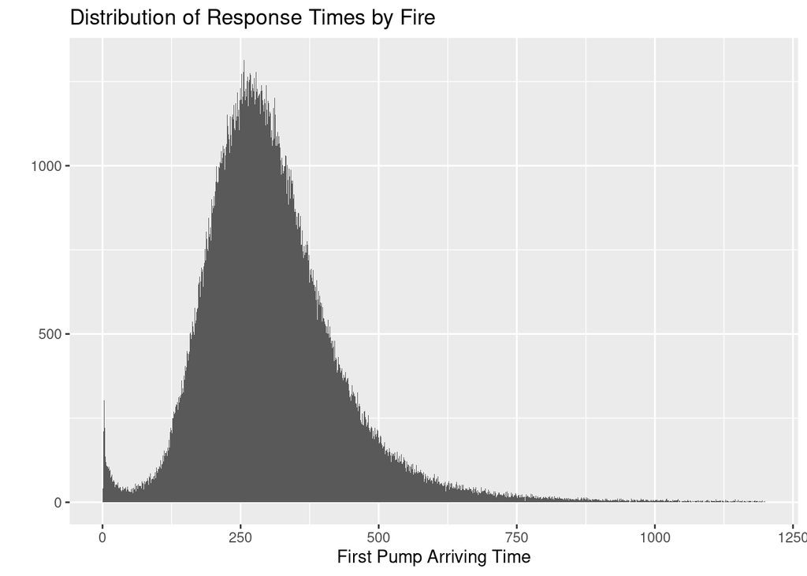

```r
ggplot(data) + geom_histogram(aes(FirstPumpArriving_AttendanceTime), binwidth= 1) + labs(x = "First Pump Arriving Time", y= "", title = "Distribution of Response Times by Fire")
```

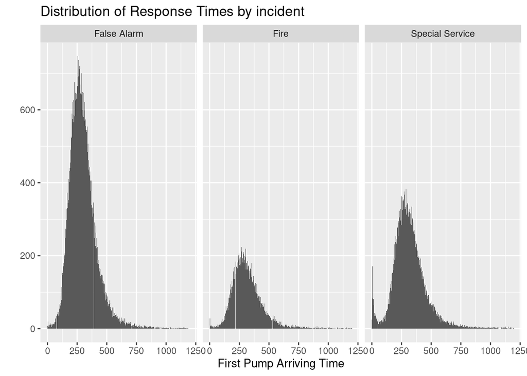

```r
ggplot(data) + geom_histogram(aes(FirstPumpArriving_AttendanceTime), binwidth= 1) + labs(x ="First Pump Arriving Time", y= "", title = "Distribution of Response Times by incident") + facet_wrap(IncidentGroup~.)
```

```r
#Addressing the GGPLOT error of 19019 rows. Checked if NA values were, and the response was TRUE
nrow(data[is.na(data$FirstPumpArriving_AttendanceTime == "NA"),])
```

```
## [1] 19019
```

#Task 3(Summary of Special Service Response Time)

```r
special.service <- filter(data,IncidentGroup == "Special Service")

group <- group_by(special.service,SpecialServiceType)

summarize (group,Count = n(),Mean = mean(FirstPumpArriving_AttendanceTime,na.rm=T),Percentile10 = quantile(FirstPumpArriving_AttendanceTime,.1,na.rm=T),Percentile90 = quantile(FirstPumpArriving_AttendanceTime,.9,na.rm=T))
```

```
## # A tibble: 21 × 5
##    SpecialServiceType           Count  Mean Percentile10 Percentile90
##    <chr>                        <int> <dbl>        <dbl>        <dbl>
##  1 Advice Only                   1867  320.         188          462.
##  2 Animal assistance incidents   2300  341.         190          517.
##  3 Assist other agencies         4529  317.         182          462
##  4 Effecting entry/exit         24142  317.         182          470
##  5 Evacuation (no fire)           667  327.         192.         474.
##  6 Flooding                     22853  328.         191          485
##  7 Hazardous Materials incident  2547  316.         185          463.
##  8 Lift Release                 15534  307.         178          450
##  9 Making Safe (not RTC)         3408  321.         177          494
## 10 Medical Incident              2190  222.           8          433
## # … with 11 more rows
```

#Task 4 ($t$-testing) Running a two sample t-test by separating the samples

```r
Ealing.Greenwich <- data %>% filter(IncGeo_BoroughName == "EALING" | IncGeo_BoroughName == "GREENWICH")

Ealing.Greenwich$IncGeo_BoroughName <- as.factor(Ealing.Greenwich$IncGeo_BoroughName)

Ealing.Greenwich.Goup <- Ealing.Greenwich %>% group_by(IncGeo_BoroughName) %>% summarise(Mean = mean(FirstPumpArriving_AttendanceTime), sd_time = sd(FirstPumpArriving_AttendanceTime), count = n())

t.test(FirstPumpArriving_AttendanceTime~IncGeo_BoroughName, data = Ealing.Greenwich)
```

```
##
##  Welch Two Sample t-test
##
## data:  FirstPumpArriving_AttendanceTime by IncGeo_BoroughName
## t = 2.8542, df = 19303, p-value = 0.00432
## alternative hypothesis: true difference in means between group EALING and group GREENWICH is not equal to 0
## 95 percent confidence interval:
##  1.739777 9.368041
## sample estimates:
##    mean in group EALING mean in group GREENWICH
##                316.9342                311.3803
```

```r
# comparision of the mean response times in Ealing to those in Greenwich by two sample t test by estimation.

FPA_Atten <- lm(FirstPumpArriving_AttendanceTime~IncGeo_BoroughName, data = Ealing.Greenwich)

FPA_Atten_emmeans <- emmeans(FPA_Atten, ~IncGeo_BoroughName)
summary(FPA_Atten_emmeans)
```

```
##  IncGeo_BoroughName emmean   SE    df lower.CL upper.CL
##  EALING                317 1.34 19445      314      320
##  GREENWICH             311 1.42 19445      309      314
##
## Confidence level used: 0.95
```

```r
FPA_Atten_contrast <- confint(pairs(FPA_Atten_emmeans))
summary(FPA_Atten_contrast)
```

```
##    contrast            estimate           SE             df           lower.CL        upper.CL
##  Length:1           Min.   :5.554   Min.   :1.95   Min.   :19445   Min.   :1.731   Min.   :9.377
##  Class :character   1st Qu.:5.554   1st Qu.:1.95   1st Qu.:19445   1st Qu.:1.731   1st Qu.:9.377
##  Mode  :character   Median :5.554   Median :1.95   Median :19445   Median :1.731   Median :9.377
##                     Mean   :5.554   Mean   :1.95   Mean   :19445   Mean   :1.731   Mean   :9.377
##                     3rd Qu.:5.554   3rd Qu.:1.95   3rd Qu.:19445   3rd Qu.:1.731   3rd Qu.:9.377
##                     Max.   :5.554   Max.   :1.95   Max.   :19445   Max.   :1.731   Max.   :9.377
```

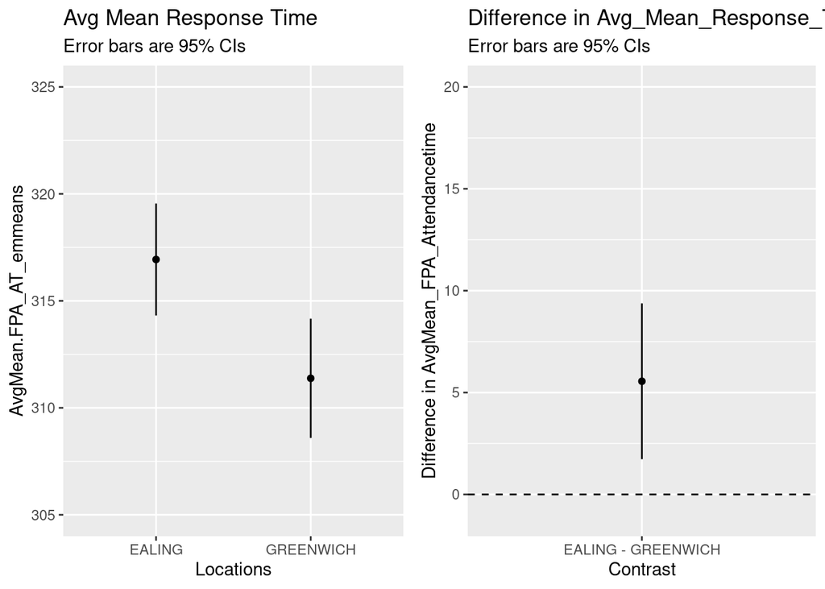

```r
#Plotting Contrast

grid.arrange(
    ggplot(summary(FPA_Atten_emmeans), aes(x= IncGeo_BoroughName, y=emmean, ymin=lower.CL, ymax=upper.CL)) +
        geom_point() + geom_linerange() +
        labs(y="AvgMean.FPA_AT_emmeans", x="Locations", subtitle="Error bars are 95% CIs", title="Avg Mean Response Time") + ylim(305, 325),
    ggplot(FPA_Atten_contrast, aes(x=contrast, y=estimate, ymin=lower.CL, ymax=upper.CL)) +
        geom_point() + geom_linerange() +
        labs(y="Difference in AvgMean_FPA_Attendancetime", x="Contrast", subtitle="Error bars are 95% CIs", title="Difference in Avg_Mean_Response_Time") + ylim(-1,20) +
        geom_hline(yintercept=0, lty=2),
    ncol=2
)
```

Report: Task 1 (The request):

H0: No significant difference between the mean time of first time response between Ealing and Greenwich.

H1: Significant difference between the mean time of of first response between Ealing and Greenwich.

Task4: Two sample t-test is used to measure if there is a significant difference between the mean response time for Ealing and Greenwich and also the absolute difference in the average response time of Ealing and Greenwich.

1. Testing the difference using NULL HYPOTHESIS SIGNIFICANCE TESTING(NHST): After the two-sample t-test we found that the t-value is 2.8542 and the degree of freedom is 19303, and p value is 0.00432 which does tell us that it is significant and to strengthen this interpretation the confidence interval is 95%, for that we work on our two ends of the limit on our sample mean, and after we are done with this upper and lower bound, these limits tell us the ranges our true population of the mean is likely to be in. We also found out that the p value is significant, and through this significance we can reject the null hypothesis and we can take the alternative hypothesis. Conclusively, the difference in mean response time is not zero.
2. We used estimation in finding out the difference of mean response time in Ealing and Greenwich. We use estimation when there is a random component to the data. The mean response time for Ealing is 317 and for Greenwich it is 311. And as discussed above, we set the limits, the limits set are 314 and 320 for Ealing and 309 and 314 for Greenwich, but as we see that the confidence interval of 95% is there, we can assume that the population mean for Ealing and Greenwich will fall in between the limits.